# Factor Analysis

Author

Riccardo Volpato

# Data Processing

```r
library(tidyverse)
library(gtools)
library(psych)
library(faux)
library(knitr)

set.seed(8675309) # makes sure random numbers are reproducible
```

```r
# read Qualtrics data without metadata rows
file_path <- "data/pilot/TPSai_13+March+2026_10.16.csv"
raw_data <- read_csv(file_path, n_max = 2)
colnames <- names(raw_data)

# Row 2 of the file is the question text row (index 1 after skip)
question_labels <- setNames(
  sub(".* - ", "", as.character(raw_data[1, ])),
  colnames
)
raw_data <- read_csv(file_path, col_names = colnames, skip = 3)
```

```r
# define variables for questions and answers
cols_trust    <- paste0("TR_", 1:23)
cols_distrust <- paste0("DT_", 1:13)
cols_company  <- paste0("CD_", 1:7)
cols_tpsai <- c(cols_trust, cols_distrust, cols_company)

likert_levels <- c(
  "Strongly disagree" = 1,
  "Disagree" = 2,
  "Neither agree nor disagree" = 3,
  "Agree" = 4,
  "Strongly agree" = 5,
  "Don't know" = NA
)

qid_label_map <- question_labels[cols_tpsai]
qid_label_df <- tibble(id = names(qid_label_map), text = qid_label_map)
```

```r
# generate random data for code development before data collection
random_data <- as.data.frame(
  lapply(cols_tpsai, function(col) {
    sample(names(likert_levels), size=100, replace=TRUE)
  })
)
colnames(random_data) <- cols_tpsai
```

```r
analysis_data <- random_data # switch to raw_data after data collection

factors_data <- analysis_data %>%
  select(all_of(cols_tpsai))  %>%
  mutate(across(all_of(cols_tpsai), ~ likert_levels[.x]))
```

# Descriptive Statistics

We report means, standard deviations, skewness, and kurtosis for all retained items, grouped by subscale. These statistics provide a preliminary characterisation of the response distributions.

```r
item_descriptives <- function(data, item_cols, scale_name) {
  d <- data %>% select(all_of(item_cols))

  map_dfr(item_cols, ~ tibble(
    subscale    = scale_name,
    item        = .x,
    M           = round(mean(d[[.x]], na.rm = TRUE), 2),
    SD          = round(sd(d[[.x]],   na.rm = TRUE), 2),
    skew        = round(psych::skew(d[[.x]],     na.rm = TRUE), 2),
    kurt        = round(psych::kurtosi(d[[.x]],  na.rm = TRUE), 2),
  ))
}

list(Trust = cols_trust, Distrust = cols_distrust,
     "Corporate Distrust" = cols_company) %>%
  imap(~ item_descriptives(factors_data, .x, .y)) %>%
  bind_rows() %>%
  kable(
    col.names  = c("Subscale", "Item", "M", "SD", "Skew", "Kurtosis"),
    digits     = 2
  )
```

| Subscale | Item | M | SD | Skew | Kurtosis |
| --- | --- | --- | --- | --- | --- |
| Trust | TR_1 | 3.08 | 1.45 | -0.16 | -1.30 |
| Trust | TR_2 | 3.03 | 1.42 | -0.01 | -1.34 |
| Trust | TR_3 | 3.19 | 1.45 | -0.17 | -1.32 |
| Trust | TR_4 | 2.93 | 1.49 | 0.12 | -1.42 |
| Trust | TR_5 | 2.72 | 1.23 | 0.34 | -0.78 |
| Trust | TR_6 | 2.78 | 1.43 | 0.22 | -1.36 |
| Trust | TR_7 | 2.86 | 1.42 | 0.10 | -1.35 |
| Trust | TR_8 | 2.87 | 1.37 | 0.20 | -1.18 |
| Trust | TR_9 | 3.12 | 1.35 | -0.10 | -1.20 |
| Trust | TR_10 | 2.95 | 1.44 | -0.04 | -1.40 |
| Trust | TR_11 | 2.89 | 1.35 | 0.14 | -1.18 |
| Trust | TR_12 | 2.85 | 1.43 | 0.29 | -1.28 |
| Trust | TR_13 | 3.28 | 1.37 | -0.12 | -1.26 |
| Trust | TR_14 | 2.74 | 1.46 | 0.27 | -1.39 |
| Trust | TR_15 | 2.88 | 1.48 | 0.12 | -1.39 |
| Trust | TR_16 | 2.86 | 1.44 | 0.06 | -1.37 |
| Trust | TR_17 | 2.93 | 1.40 | 0.05 | -1.34 |
| Trust | TR_18 | 3.02 | 1.58 | -0.11 | -1.62 |
| Trust | TR_19 | 3.23 | 1.39 | -0.28 | -1.24 |
| Trust | TR_20 | 3.21 | 1.56 | -0.23 | -1.50 |
| Trust | TR_21 | 3.23 | 1.41 | -0.12 | -1.27 |
| Trust | TR_22 | 2.83 | 1.35 | 0.09 | -1.18 |
| Trust | TR_23 | 2.96 | 1.43 | 0.17 | -1.39 |
| Distrust | DT_1 | 3.24 | 1.38 | -0.16 | -1.28 |
| Distrust | DT_2 | 3.04 | 1.33 | 0.00 | -1.12 |
| Distrust | DT_3 | 2.95 | 1.40 | 0.06 | -1.28 |
| Distrust | DT_4 | 3.06 | 1.36 | 0.04 | -1.27 |
| Distrust | DT_5 | 2.83 | 1.39 | 0.20 | -1.27 |
| Distrust | DT_6 | 3.04 | 1.35 | -0.07 | -1.30 |
| Distrust | DT_7 | 3.03 | 1.43 | -0.08 | -1.35 |
| Distrust | DT_8 | 2.91 | 1.46 | 0.07 | -1.36 |
| Distrust | DT_9 | 3.09 | 1.32 | -0.16 | -1.17 |
| Distrust | DT_10 | 3.20 | 1.33 | -0.22 | -1.21 |
| Distrust | DT_11 | 2.82 | 1.37 | 0.41 | -1.17 |
| Distrust | DT_12 | 2.74 | 1.32 | 0.35 | -0.97 |
| Distrust | DT_13 | 3.24 | 1.42 | -0.30 | -1.22 |
| Corporate Distrust | CD_1 | 3.06 | 1.34 | -0.02 | -1.20 |
| Corporate Distrust | CD_2 | 3.10 | 1.43 | -0.09 | -1.40 |
| Corporate Distrust | CD_3 | 2.89 | 1.37 | 0.19 | -1.20 |
| Corporate Distrust | CD_4 | 3.06 | 1.51 | -0.08 | -1.46 |
| Corporate Distrust | CD_5 | 2.94 | 1.49 | 0.01 | -1.44 |
| Corporate Distrust | CD_6 | 3.06 | 1.36 | -0.05 | -1.27 |
| Corporate Distrust | CD_7 | 2.91 | 1.37 | 0.18 | -1.30 |

## Correlation Matrix

We inspect the full inter-item correlation matrix to assess the factorability of the data. Items should show moderate correlations with one another: too low and they share insufficient common variance to define a factor; too high and they may be redundant, though extreme pairs should already have been removed at the item reduction stage.

```r
cor_matrix <- cor(factors_data, use = "pairwise.complete.obs")
```

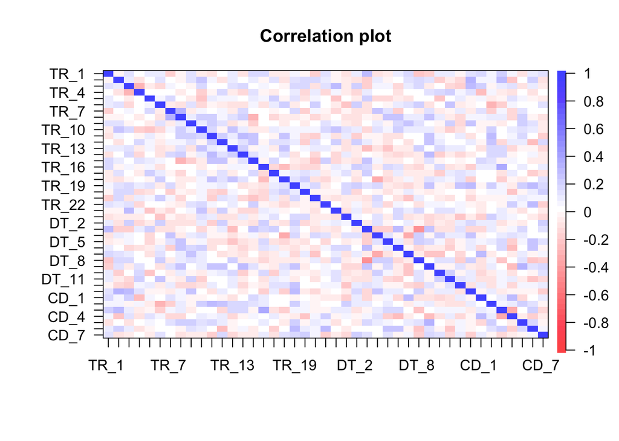

```r
cor.plot(cor_matrix, numbers = FALSE, cex = 0.5)
```

```r
kable(round(cor_matrix, 2))
```

|  | TR_1 | TR_2 | TR_3 | TR_4 | TR_5 | TR_6 | TR_7 | TR_8 | TR_9 | TR_10 | TR_11 | TR_12 | TR_13 | TR_14 | TR_15 | TR_16 | TR_17 | TR_18 | TR_19 | TR_20 | TR_21 | TR_22 | TR_23 | DT_1 | DT_2 | DT_3 | DT_4 | DT_5 | DT_6 | … |
| --- | --- | --- | --- | --- | --- | --- | --- | --- | --- | --- | --- | --- | --- | --- | --- | --- | --- | --- | --- | --- | --- | --- | --- | --- | --- | --- | --- | --- | --- | --- |
| TR_1 | 1.00 | -0.04 | 0.12 | -0.01 | 0.08 | 0.09 | -0.18 | -0.02 | 0.12 | -0.09 | -0.11 | -0.01 | 0.08 | -0.11 | 0.17 | 0.15 | -0.09 | -0.08 | 0.05 | -0.02 | -0.20 | 0.11 | -0.05 | -0.10 | 0.07 | 0.27 | -0.13 | -0.10 | 0.09 | … |
| TR_2 | -0.04 | 1.00 | 0.09 | -0.14 | 0.00 | 0.14 | 0.01 | -0.04 | 0.12 | 0.24 | 0.04 | -0.11 | 0.07 | -0.01 | 0.09 | -0.04 | 0.14 | -0.14 | 0.10 | 0.15 | 0.17 | 0.09 | -0.04 | -0.09 | -0.11 | -0.20 | 0.07 | -0.03 | 0.02 | … |
| TR_3 | 0.12 | 0.09 | 1.00 | -0.31 | -0.07 | -0.17 | 0.04 | -0.01 | -0.03 | 0.17 | -0.02 | 0.00 | 0.11 | 0.17 | 0.00 | 0.05 | -0.01 | -0.04 | 0.16 | 0.14 | -0.12 | 0.12 | 0.26 | -0.09 | 0.19 | -0.20 | 0.03 | 0.05 | -0.15 | … |
| TR_4 | -0.01 | -0.14 | -0.31 | 1.00 | 0.02 | 0.01 | -0.01 | -0.07 | 0.00 | -0.20 | -0.04 | 0.14 | -0.10 | -0.18 | 0.13 | -0.05 | -0.07 | 0.00 | 0.06 | -0.15 | 0.06 | -0.16 | 0.06 | -0.07 | -0.16 | 0.08 | 0.00 | -0.01 | -0.10 | … |
| TR_5 | 0.08 | 0.00 | -0.07 | 0.02 | 1.00 | 0.03 | 0.14 | -0.02 | -0.08 | -0.23 | 0.10 | 0.03 | 0.05 | -0.02 | 0.08 | 0.06 | 0.19 | -0.05 | 0.10 | -0.12 | 0.06 | 0.01 | -0.24 | 0.02 | -0.07 | 0.20 | -0.14 | -0.16 | -0.06 | … |
| TR_6 | 0.09 | 0.14 | -0.17 | 0.01 | 0.03 | 1.00 | -0.10 | -0.13 | 0.10 | -0.15 | -0.02 | -0.06 | -0.10 | -0.12 | 0.04 | -0.13 | 0.06 | 0.20 | -0.09 | 0.00 | 0.21 | -0.01 | -0.09 | -0.25 | 0.18 | -0.11 | 0.00 | -0.04 | 0.07 | … |
| TR_7 | -0.18 | 0.01 | 0.04 | -0.01 | 0.14 | -0.10 | 1.00 | 0.31 | -0.09 | 0.03 | 0.02 | 0.03 | -0.07 | 0.16 | 0.01 | -0.01 | -0.05 | -0.01 | 0.16 | -0.20 | 0.06 | -0.03 | -0.17 | -0.05 | -0.12 | -0.11 | 0.22 | 0.12 | -0.20 | … |
| TR_8 | -0.02 | -0.04 | -0.01 | -0.07 | -0.02 | -0.13 | 0.31 | 1.00 | 0.09 | 0.21 | 0.18 | 0.03 | 0.12 | 0.19 | -0.32 | -0.01 | -0.14 | -0.09 | -0.07 | -0.06 | -0.15 | -0.07 | 0.02 | -0.11 | -0.10 | -0.02 | -0.09 | 0.25 | 0.25 | … |
| TR_9 | 0.12 | 0.12 | -0.03 | 0.00 | -0.08 | 0.10 | -0.09 | 0.09 | 1.00 | 0.10 | 0.21 | 0.13 | -0.11 | -0.03 | -0.20 | 0.01 | -0.01 | -0.09 | -0.01 | -0.08 | 0.00 | 0.10 | 0.04 | -0.06 | -0.10 | 0.00 | 0.07 | -0.03 | 0.14 | … |
| TR_10 | -0.09 | 0.24 | 0.17 | -0.20 | -0.23 | -0.15 | 0.03 | 0.21 | 0.10 | 1.00 | 0.16 | -0.02 | 0.24 | 0.06 | -0.09 | -0.08 | 0.09 | 0.03 | 0.06 | 0.04 | 0.02 | 0.14 | 0.23 | 0.14 | 0.07 | -0.16 | 0.10 | 0.03 | 0.19 | … |
| TR_11 | -0.11 | 0.04 | -0.02 | -0.04 | 0.10 | -0.02 | 0.02 | 0.18 | 0.21 | 0.16 | 1.00 | 0.20 | 0.07 | 0.29 | 0.22 | 0.00 | -0.02 | 0.22 | 0.05 | -0.15 | -0.20 | 0.04 | -0.12 | 0.06 | -0.20 | -0.05 | -0.04 | -0.11 | -0.14 | … |
| TR_12 | -0.01 | -0.11 | 0.00 | 0.14 | 0.03 | -0.06 | 0.03 | 0.03 | 0.13 | -0.02 | 0.20 | 1.00 | 0.03 | 0.11 | 0.24 | -0.04 | 0.12 | 0.11 | 0.08 | -0.18 | 0.10 | 0.02 | 0.18 | -0.13 | 0.18 | 0.06 | -0.03 | -0.11 | 0.00 | … |
| TR_13 | 0.08 | 0.07 | 0.11 | -0.10 | 0.05 | -0.10 | -0.07 | 0.12 | -0.11 | 0.24 | 0.07 | 0.03 | 1.00 | 0.21 | -0.03 | 0.03 | -0.09 | 0.24 | 0.01 | 0.05 | 0.08 | 0.07 | -0.03 | -0.12 | -0.10 | -0.27 | -0.11 | -0.23 | -0.06 | … |
| TR_14 | -0.11 | -0.01 | 0.17 | -0.18 | -0.02 | -0.12 | 0.16 | 0.19 | -0.03 | 0.06 | 0.29 | 0.11 | 0.21 | 1.00 | 0.11 | 0.05 | -0.01 | 0.13 | -0.12 | 0.00 | -0.15 | 0.01 | -0.16 | 0.07 | -0.07 | 0.01 | -0.06 | -0.12 | -0.15 | … |
| TR_15 | 0.17 | 0.09 | 0.00 | 0.13 | 0.08 | 0.04 | 0.01 | -0.32 | -0.20 | -0.09 | 0.22 | 0.24 | -0.03 | 0.11 | 1.00 | -0.05 | 0.15 | 0.01 | -0.07 | -0.13 | -0.24 | 0.20 | -0.17 | -0.08 | -0.12 | 0.24 | 0.05 | -0.09 | -0.07 | … |
| TR_16 | 0.15 | -0.04 | 0.05 | -0.05 | 0.06 | -0.13 | -0.01 | -0.01 | 0.01 | -0.08 | 0.00 | -0.04 | 0.03 | 0.05 | -0.05 | 1.00 | -0.17 | -0.28 | -0.12 | -0.15 | -0.15 | -0.04 | 0.06 | 0.05 | 0.18 | 0.16 | -0.10 | 0.14 | 0.13 | … |
| TR_17 | -0.09 | 0.14 | -0.01 | -0.07 | 0.19 | 0.06 | -0.05 | -0.14 | -0.01 | 0.09 | -0.02 | 0.12 | -0.09 | -0.01 | 0.15 | -0.17 | 1.00 | 0.02 | 0.08 | 0.12 | 0.09 | -0.08 | 0.03 | 0.11 | -0.09 | 0.20 | 0.01 | -0.13 | 0.07 | … |
| TR_18 | -0.08 | -0.14 | -0.04 | 0.00 | -0.05 | 0.20 | -0.01 | -0.09 | -0.09 | 0.03 | 0.22 | 0.11 | 0.24 | 0.13 | 0.01 | -0.28 | 0.02 | 1.00 | 0.10 | 0.19 | -0.12 | -0.17 | -0.04 | 0.00 | -0.12 | 0.02 | -0.33 | -0.17 | -0.07 | … |
| TR_19 | 0.05 | 0.10 | 0.16 | 0.06 | 0.10 | -0.09 | 0.16 | -0.07 | -0.01 | 0.06 | 0.05 | 0.08 | 0.01 | -0.12 | -0.07 | -0.12 | 0.08 | 0.10 | 1.00 | 0.08 | 0.14 | -0.07 | 0.00 | 0.15 | 0.18 | 0.14 | 0.17 | -0.06 | -0.13 | … |
| TR_20 | -0.02 | 0.15 | 0.14 | -0.15 | -0.12 | 0.00 | -0.20 | -0.06 | -0.08 | 0.04 | -0.15 | -0.18 | 0.05 | 0.00 | -0.13 | -0.15 | 0.12 | 0.19 | 0.08 | 1.00 | -0.03 | -0.04 | -0.02 | 0.15 | -0.16 | -0.01 | -0.04 | -0.12 | -0.02 | … |
| TR_21 | -0.20 | 0.17 | -0.12 | 0.06 | 0.06 | 0.21 | 0.06 | -0.15 | 0.00 | 0.02 | -0.20 | 0.10 | 0.08 | -0.15 | -0.24 | -0.15 | 0.09 | -0.12 | 0.14 | -0.03 | 1.00 | -0.06 | -0.11 | -0.08 | -0.08 | -0.12 | 0.17 | 0.01 | -0.10 | … |
| TR_22 | 0.11 | 0.09 | 0.12 | -0.16 | 0.01 | -0.01 | -0.03 | -0.07 | 0.10 | 0.14 | 0.04 | 0.02 | 0.07 | 0.01 | 0.20 | -0.04 | -0.08 | -0.17 | -0.07 | -0.04 | -0.06 | 1.00 | -0.01 | -0.09 | 0.05 | -0.07 | 0.14 | -0.14 | 0.05 | … |
| TR_23 | -0.05 | -0.04 | 0.26 | 0.06 | -0.24 | -0.09 | -0.17 | 0.02 | 0.04 | 0.23 | -0.12 | 0.18 | -0.03 | -0.16 | -0.17 | 0.06 | 0.03 | -0.04 | 0.00 | -0.02 | -0.11 | -0.01 | 1.00 | -0.12 | 0.06 | -0.11 | -0.07 | -0.02 | 0.17 | … |
| DT_1 | -0.10 | -0.09 | -0.09 | -0.07 | 0.02 | -0.25 | -0.05 | -0.11 | -0.06 | 0.14 | 0.06 | -0.13 | -0.12 | 0.07 | -0.08 | 0.05 | 0.11 | 0.00 | 0.15 | 0.15 | -0.08 | -0.09 | -0.12 | 1.00 | 0.03 | -0.01 | 0.12 | -0.08 | 0.14 | … |
| DT_2 | 0.07 | -0.11 | 0.19 | -0.16 | -0.07 | 0.18 | -0.12 | -0.10 | -0.10 | 0.07 | -0.20 | 0.18 | -0.10 | -0.07 | -0.12 | 0.18 | -0.09 | -0.12 | 0.18 | -0.16 | -0.08 | 0.05 | 0.06 | 0.03 | 1.00 | -0.09 | 0.11 | -0.03 | 0.00 | … |
| DT_3 | 0.27 | -0.20 | -0.20 | 0.08 | 0.20 | -0.11 | -0.11 | -0.02 | 0.00 | -0.16 | -0.05 | 0.06 | -0.27 | 0.01 | 0.24 | 0.16 | 0.20 | 0.02 | 0.14 | -0.01 | -0.12 | -0.07 | -0.11 | -0.01 | -0.09 | 1.00 | -0.21 | -0.19 | 0.26 | … |
| DT_4 | -0.13 | 0.07 | 0.03 | 0.00 | -0.14 | 0.00 | 0.22 | -0.09 | 0.07 | 0.10 | -0.04 | -0.03 | -0.11 | -0.06 | 0.05 | -0.10 | 0.01 | -0.33 | 0.17 | -0.04 | 0.17 | 0.14 | -0.07 | 0.12 | 0.11 | -0.21 | 1.00 | 0.13 | -0.05 | … |
| DT_5 | -0.10 | -0.03 | 0.05 | -0.01 | -0.16 | -0.04 | 0.12 | 0.25 | -0.03 | 0.03 | -0.11 | -0.11 | -0.23 | -0.12 | -0.09 | 0.14 | -0.13 | -0.17 | -0.06 | -0.12 | 0.01 | -0.14 | -0.02 | -0.08 | -0.03 | -0.19 | 0.13 | 1.00 | 0.07 | … |
| DT_6 | 0.09 | 0.02 | -0.15 | -0.10 | -0.06 | 0.07 | -0.20 | 0.25 | 0.14 | 0.19 | -0.14 | 0.00 | -0.06 | -0.15 | -0.07 | 0.13 | 0.07 | -0.07 | -0.13 | -0.02 | -0.10 | 0.05 | 0.17 | 0.14 | 0.00 | 0.26 | -0.05 | 0.07 | 1.00 | … |
| DT_7 | 0.17 | 0.11 | 0.09 | 0.01 | -0.14 | 0.10 | -0.01 | 0.07 | 0.22 | 0.07 | 0.00 | -0.13 | -0.06 | -0.11 | 0.00 | -0.12 | -0.10 | 0.02 | -0.15 | 0.06 | -0.25 | -0.01 | 0.07 | -0.13 | 0.07 | -0.07 | -0.35 | -0.10 | -0.03 | … |
| DT_8 | -0.23 | 0.17 | 0.15 | 0.02 | 0.00 | 0.19 | -0.07 | 0.07 | 0.10 | 0.08 | 0.01 | -0.01 | 0.21 | -0.10 | -0.09 | -0.16 | -0.10 | -0.08 | -0.06 | -0.04 | 0.09 | -0.10 | 0.14 | -0.10 | -0.02 | -0.45 | 0.20 | 0.18 | -0.17 | … |
| DT_9 | -0.19 | 0.10 | -0.06 | 0.13 | 0.02 | -0.11 | 0.12 | 0.23 | 0.01 | 0.07 | 0.25 | 0.23 | -0.01 | 0.27 | 0.11 | -0.04 | -0.09 | 0.13 | 0.22 | -0.08 | 0.02 | 0.02 | -0.01 | -0.18 | -0.16 | 0.25 | -0.06 | 0.15 | -0.07 | … |
| DT_10 | 0.09 | -0.19 | 0.00 | 0.15 | -0.24 | 0.00 | -0.07 | 0.06 | -0.04 | -0.07 | 0.05 | 0.10 | 0.16 | -0.18 | -0.04 | 0.17 | -0.19 | 0.08 | -0.05 | -0.05 | -0.06 | 0.02 | 0.13 | -0.11 | -0.07 | -0.13 | 0.19 | 0.06 | -0.07 | … |
| DT_11 | 0.08 | -0.09 | -0.14 | 0.19 | 0.02 | 0.24 | -0.06 | -0.07 | 0.18 | -0.20 | 0.00 | -0.01 | 0.08 | -0.08 | 0.01 | -0.12 | 0.07 | 0.05 | -0.10 | 0.00 | -0.11 | 0.01 | 0.10 | -0.08 | -0.13 | -0.11 | 0.08 | -0.14 | -0.19 | … |
| DT_12 | -0.05 | -0.17 | -0.21 | 0.05 | 0.07 | -0.09 | 0.06 | -0.17 | -0.16 | -0.11 | 0.08 | 0.02 | 0.06 | -0.17 | -0.03 | -0.07 | 0.12 | 0.12 | 0.22 | 0.01 | -0.01 | 0.04 | 0.04 | -0.23 | 0.06 | 0.10 | 0.08 | -0.05 | -0.05 | … |
| DT_13 | 0.13 | 0.30 | 0.26 | 0.13 | -0.05 | -0.04 | -0.08 | 0.05 | 0.24 | 0.02 | -0.10 | 0.09 | 0.00 | -0.07 | 0.01 | -0.20 | 0.08 | -0.18 | 0.26 | -0.09 | -0.14 | -0.04 | 0.00 | -0.09 | 0.17 | -0.17 | 0.23 | 0.08 | 0.06 | … |
| CD_1 | 0.17 | 0.02 | 0.19 | -0.26 | 0.02 | -0.01 | 0.12 | 0.03 | -0.04 | -0.05 | -0.01 | -0.05 | -0.10 | -0.02 | 0.14 | 0.06 | -0.02 | 0.00 | -0.04 | -0.01 | -0.02 | -0.06 | -0.07 | -0.20 | 0.07 | -0.16 | -0.04 | 0.03 | -0.18 | … |
| CD_2 | 0.05 | 0.02 | -0.02 | 0.03 | -0.08 | -0.30 | -0.20 | 0.06 | -0.03 | 0.19 | 0.26 | 0.24 | 0.15 | 0.17 | 0.12 | 0.07 | -0.01 | 0.01 | 0.19 | 0.02 | -0.05 | -0.01 | 0.00 | 0.19 | 0.10 | 0.07 | 0.01 | 0.06 | -0.01 | … |
| CD_3 | 0.19 | 0.27 | 0.09 | -0.09 | -0.04 | -0.21 | 0.06 | 0.07 | -0.06 | 0.02 | -0.02 | -0.16 | 0.17 | 0.14 | -0.02 | 0.36 | -0.12 | -0.19 | 0.04 | 0.06 | -0.03 | -0.03 | 0.08 | 0.07 | -0.11 | -0.06 | 0.08 | 0.16 | 0.16 | … |
| CD_4 | 0.03 | -0.23 | 0.11 | -0.11 | 0.11 | 0.02 | -0.14 | -0.18 | 0.01 | 0.06 | 0.04 | 0.08 | -0.16 | -0.04 | 0.04 | -0.02 | 0.09 | -0.04 | -0.06 | -0.22 | 0.02 | 0.21 | -0.04 | 0.03 | -0.02 | 0.05 | 0.13 | -0.21 | -0.27 | … |
| CD_5 | -0.10 | 0.00 | -0.11 | 0.02 | 0.03 | 0.02 | 0.10 | 0.18 | 0.21 | 0.11 | 0.14 | 0.06 | -0.04 | 0.01 | -0.01 | 0.09 | 0.00 | -0.07 | 0.18 | -0.03 | 0.08 | 0.03 | -0.12 | -0.02 | -0.08 | 0.17 | 0.09 | 0.05 | 0.01 | … |
| CD_6 | 0.06 | 0.20 | 0.07 | -0.12 | -0.02 | 0.01 | 0.01 | -0.04 | 0.10 | 0.06 | -0.01 | -0.26 | -0.03 | 0.04 | -0.07 | 0.01 | -0.19 | 0.00 | 0.29 | 0.08 | 0.04 | 0.28 | -0.01 | -0.08 | -0.02 | 0.01 | 0.01 | 0.24 | 0.22 | … |
| CD_7 | 0.12 | -0.13 | -0.08 | 0.00 | -0.07 | 0.10 | 0.01 | -0.11 | -0.07 | -0.09 | -0.18 | 0.16 | -0.15 | -0.07 | -0.07 | 0.08 | -0.13 | 0.13 | 0.16 | 0.20 | 0.03 | -0.19 | -0.08 | -0.15 | 0.18 | 0.10 | -0.02 | 0.11 | -0.03 | … |

```r
write.csv(round(cor_matrix, 2), "data/pilot/sample_correlation_matrix.csv")
```

## Sub-scales correlation

We report Spearman correlations between the three TPSai subscale mean scores (Trust, Distrust, and Corporate Distrust) to examine their inter-relationships prior to factor analysis. Spearman correlations are used as a rank-based, distribution-free alternative to Pearson, which is more appropriate for composite scores derived from ordinal Likert items (Boateng et al. 2018). Based on the theoretical structure of the scale, we expect Trust and Distrust to be moderately negatively correlated, reflecting their conceptual opposition yet potential independence/coexistence (McKnight and Chervany 2001; Scharowski et al. 2024). The relationship of Corporate Distrust with the other two subscales is more exploratory at this stage. Notably strong or unexpected correlations between subscales would suggest greater construct overlap than theorised, with implications for the factor structure identified in the EFA.

```r
subscales <- factors_data %>%
  mutate(
    Trust    = rowMeans(pick(all_of(cols_trust)),    na.rm = TRUE),
    Distrust = rowMeans(pick(all_of(cols_distrust)), na.rm = TRUE),
    "Corporate Distrust"  = rowMeans(pick(all_of(cols_company)),  na.rm = TRUE)
  ) %>%
  select(Trust, Distrust, "Corporate Distrust")


cor_subscales <- cor(subscales, method = "spearman", use = "pairwise.complete.obs")

cor_subscales %>%
  as.data.frame() %>%
  rownames_to_column("S1") %>%
  pivot_longer(-S1, names_to = "S2", values_to = "r") %>%
  filter(S1 < S2) %>%
  kable(digits = 2)
```

| S1 | S2 | r |
| --- | --- | --- |
| Distrust | Trust | -0.07 |
| Corporate Distrust | Trust | 0.14 |
| Corporate Distrust | Distrust | -0.09 |

# Factor Analysis

## Exploratory Factor Analysis

Boateng, Godfred O., Torsten B. Neilands, Edward A. Frongillo, Hugo R. Melgar-Quiñonez, and Sera L. Young. 2018. “Best Practices for Developing and Validating Scales for Health, Social, and Behavioral Research: A Primer.” *Frontiers in Public Health* 6 (June). https://doi.org/10.3389/fpubh.2018.00149.

McKnight, D. Harrison, and Norman L. Chervany. 2001. “Trust and Distrust Definitions: One Bite at a Time.” In, edited by Rino Falcone, Munindar Singh, and Yao-Hua Tan, 2246:27–54. Berlin, Heidelberg: Springer Berlin Heidelberg. https://doi.org/10.1007/3-540-45547-7_3.

Scharowski, Nicolas, Sebastian A. C. Perrig, Lena Fanya Aeschbach, Nick von Felten, Klaus Opwis, Philipp Wintersberger, and Florian Brühlmann. 2024. “To Trust or Distrust Trust Measures: Validating Questionnaires for Trust in AI.” arXiv. https://doi.org/10.48550/arXiv.2403.00582.